# Developing Data Products: Week 4 Assignment

April 07, 2017

## Application Description

This is simple data exploration application which presents the following information about a selected dataset:

- data summary
- data view
- observations

The application has been implemented in Shiny using RStudio and is hosted on the [ShinyApps.io](https://ij8585.shinyapps.io/coursera/). The R source code is available at [GitHub](https://github.com/ij8585/ddp).

There are currently three datasets available for data exploration: *cars*, *pressure*, *women*

## Data Summary

The basic statistics are computed using **summary** function i.e.:

```r
    summary(pressure)
```

```
    temperature     pressure
   Min.   :  0   Min.   :  0.0002
   1st Qu.: 90   1st Qu.:  0.1800
   Median :180   Median :  8.8000
   Mean   :180   Mean   :124.3367
   3rd Qu.:270   3rd Qu.:126.5000
   Max.   :360   Max.   :806.0000
```

In the Shiny server.R file the function is invoked as follows

```r
  output$summary <- renderPrint({ summary( datasetInput()) })
```

*Note: The summary is based on the full dataset.*

## Data View

###### The data points are visualized using **plot** function and **lowess** function is used to calculate the smoother line.

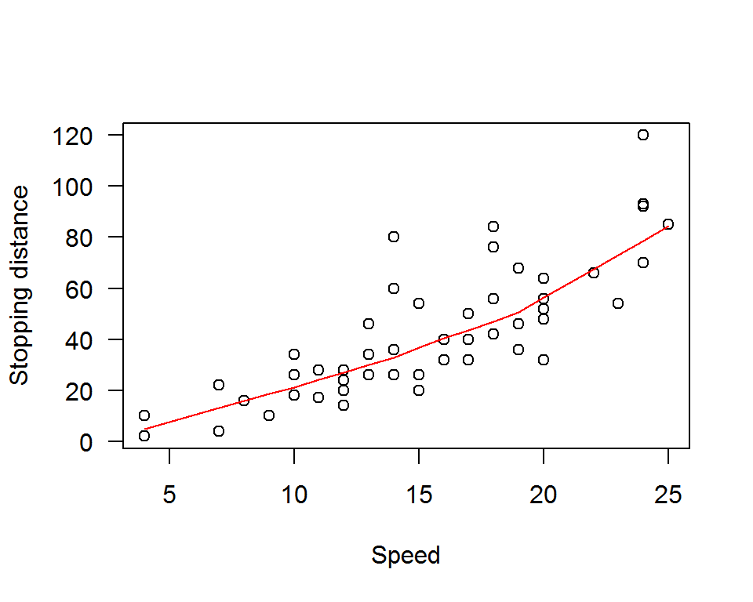

###### *Note: the size of the points and color of the line can be changed in the application using the widgets in the control panel.*

## Observations

The observations are displayed using **head** function i.e.:

```r
    head(pressure,5)
```

```
    temperature pressure
  1           0   0.0002
  2          20   0.0012
  3          40   0.0060
  4          60   0.0300
  5          80   0.0900
```

In the Shiny server.R file the function is invoked as follows

```r
  output$view <- renderTable({ head(datasetInput(), n = input$obs) })
```

*Note: the number of the displayed observations can be changed in the control panel.*